# Module 1, Lesson 1:

Welcome to the independent guide for the first lesson of Module 1.

Open a new R script. At the top of this script, load the `tidyverse` by writing the following in your script:

```r
library(tidyverse)
```

There are many reasons why it’s helpful to be able to generate random numbers from a distribution. Here, it will be useful to demonstrate the t-test.

However, computers cannot generate truly random numbers but rather so-called *pseudo* random numbers. Pseudo random numbers appear to be random but are actually pre-determined sequences of numbers, so that if you start at the same point in the seuence as someone else, you will obtain the same set of “random” numbers.

Now, to see how this works, let us sample twenty-five numbers from a normal distribution with mean 4.5 and standard deviation 0.5 using the `rnorm` function, which is intended to make you think of ‘random normal’:

```r
rnorm(n = 25, mean = 4.5, sd = 0.5)
```

```
 [1] 4.186773 4.591822 4.082186 5.297640 4.664754 4.089766 4.743715 4.869162 4.787891
[10] 4.347306 5.255891 4.694922 4.189380 3.392650 5.062465 4.477533 4.491905 4.971918
[19] 4.910611 4.796951 4.959489 4.891068 4.537282 3.505324 4.809913
```

Having generated some (pseudo) random numbers, we have advanced along the pre-determined sequence of numbers, meaning that if we run this same code again we will get a different set of numbers than above:

```r
rnorm(n = 25, mean = 4.5, sd = 0.5)
```

[output not shown]

```r
x
```

[output not shown]

```
 [1] 4.186773 4.591822 4.082186 5.297640 4.664754 4.089766 4.743715 4.869162 4.787891
[10] 4.347306 5.255891 4.694922 4.189380 3.392650 5.062465 4.477533 4.491905 4.971918
[19] 4.910611 4.796951 4.959489 4.891068 4.537282 3.505324 4.809913
```

Notice how these 25 numbers are *identical* to the first 25 numbers above. We can visualize these numbers using `ggplot`:

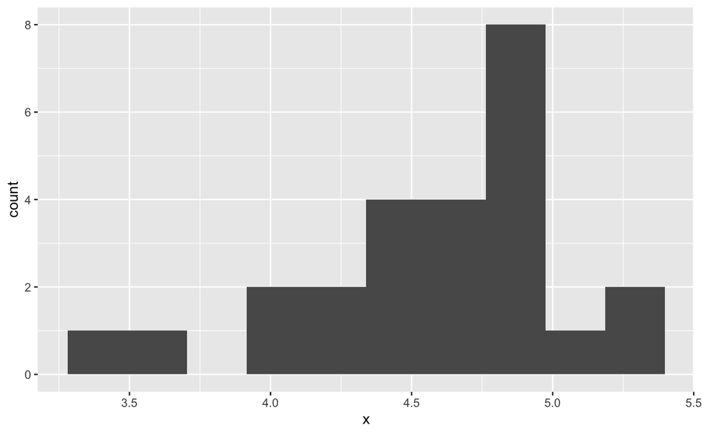